# Assignment 5: Space-Time Prediction of Bike Share Demand: Philadelphia Indego

Author

Xiaoqing (Kelsey) Chen

Published

November 24, 2025

# Setup

## Load Libraries

```r
# Core tidyverse
library(tidyverse)
library(lubridate)

# Spatial data
library(sf)
library(tigris)

# Census data
library(tidycensus)

# Weather data
library(riem)  # For Philadelphia weather from ASOS stations

# Visualization
library(viridis)
library(gridExtra)
library(knitr)
library(kableExtra)

# here!
library(here)
# Get rid of scientific notation. We gotta look good!
options(scipen = 999)
```

## Define Themes

```r
plotTheme <- theme(
  plot.title = element_text(size = 14, face = "bold"),
  plot.subtitle = element_text(size = 10),
  plot.caption = element_text(size = 8),
  axis.text.x = element_text(size = 10, angle = 45, hjust = 1),
  axis.text.y = element_text(size = 10),
  axis.title = element_text(size = 11, face = "bold"),
  panel.background = element_blank(),
  panel.grid.major = element_line(colour = "#D0D0D0", size = 0.2),
  panel.grid.minor = element_blank(),
  axis.ticks = element_blank(),
  legend.position = "right"
)

mapTheme <- theme(
  plot.title = element_text(size = 14, face = "bold"),
  plot.subtitle = element_text(size = 10),
  plot.caption = element_text(size = 8),
  axis.line = element_blank(),
  axis.text = element_blank(),
  axis.ticks = element_blank(),
  axis.title = element_blank(),
  panel.background = element_blank(),
  panel.border = element_blank(),
  panel.grid.major = element_line(colour = 'transparent'),
  panel.grid.minor = element_blank(),
  legend.position = "right",
  plot.margin = margin(1, 1, 1, 1, 'cm'),
  legend.key.height = unit(1, "cm"),
  legend.key.width = unit(0.2, "cm")
)

palette5 <- c("#eff3ff", "#bdd7e7", "#6baed6", "#3182bd", "#08519c")
```

## Set Census API Key

```r
census_api_key("e17c1c6ce413dc3faca31a17a58ab3374404bb9e", overwrite = TRUE, install = TRUE)
```

# Part 1: Replicate with Different Quarter (Q4 2024)

## 1.1 Data Import & Preparation

I downloaded the data for Q4 2024 in HW5, because i want to see the sequential change from Q4 2024 to Q1 2025.

### Load Indego Trip Data (Q4 2024)

```r
# Read Q4 2024 data
indego <- read_csv(here("assignment_5/data/indego-trips-2024-q4.csv"))

# Quick look at the data
glimpse(indego)
```

```
Rows: 299,121
Columns: 15
$ trip_id             <dbl> 1050296434, 1050293063, 1050296229, 1050276817, 10…
$ duration            <dbl> 22, 8, 12, 1, 5, 9, 5, 6, 16, 16, 16, 39, 6, 40, 1…
$ start_time          <chr> "10/1/2024 0:00", "10/1/2024 0:06", "10/1/2024 0:0…
$ end_time            <chr> "10/1/2024 0:22", "10/1/2024 0:14", "10/1/2024 0:1…
$ start_station       <dbl> 3322, 3166, 3007, 3166, 3075, 3166, 3030, 3010, 33…
$ start_lat           <dbl> 39.93638, 39.97195, 39.94517, 39.97195, 39.96718, …
$ start_lon           <dbl> -75.15526, -75.13445, -75.15993, -75.13445, -75.16…
$ end_station         <dbl> 3375, 3017, 3244, 3166, 3102, 3008, 3203, 3163, 33…
$ end_lat             <dbl> 39.96036, 39.98003, 39.93865, 39.97195, 39.96759, …
$ end_lon             <dbl> -75.14020, -75.14371, -75.16674, -75.13445, -75.17…
$ bike_id             <chr> "03580", "05386", "18082", "02729", "18519", "0272…
$ plan_duration       <dbl> 365, 365, 365, 1, 30, 1, 365, 365, 30, 30, 30, 30,…
$ trip_route_category <chr> "One Way", "One Way", "One Way", "Round Trip", "On…
$ passholder_type     <chr> "Indego365", "Indego365", "Indego365", "Walk-up", …
$ bike_type           <chr> "standard", "standard", "electric", "standard", "e…
```

It has the same categories with Q1 2025, but it contains more data rows.

### Examine the Data Structure

```r
cat("Total trips in Q4 2024:", nrow(indego), "\n")
```

```
Total trips in Q4 2024: 299121
```

```r
# Date range
cat("Date range:",
    min(mdy_hm(indego$start_time)), "to",
    max(mdy_hm(indego$start_time)), "\n")
```

```
Date range: 1727740800 to 1735689360
```

```r
cat("Unique start stations:", length(unique(indego$start_station)), "\n")
```

```
Unique start stations: 256
```

```r
# Trip types
table(indego$trip_route_category)
```

```
   One Way Round Trip
    282675      16446
```

```r
# Passholder types
table(indego$passholder_type)
```

```
  Day Pass   Indego30  Indego365 IndegoFlex       NULL    Walk-up
     10711     159895     112690          1       1165      14659
```

```r
# Bike types
table(indego$bike_type)
```

```
electric standard
  175503   123618
```

### Create Time Bins

We need to aggregate trips into hourly intervals for our panel data structure.

```r
indego <- indego %>%
  mutate(
    # Parse datetime
    start_datetime = mdy_hm(start_time),
    end_datetime = mdy_hm(end_time),

    # Create hourly bins
    interval60 = floor_date(start_datetime, unit = "hour"),

    # Extract time features
    week = week(interval60),
    month = month(interval60, label = TRUE),
    dotw = wday(interval60, label = TRUE),
    hour = hour(interval60),
    date = as.Date(interval60),

    # Create useful indicators
    weekend = ifelse(dotw %in% c("Sat", "Sun"), 1, 0),
    rush_hour = ifelse(hour %in% c(7, 8, 9, 16, 17, 18), 1, 0)
  )

# Look at temporal features
head(indego %>% select(start_datetime, interval60, week, dotw, hour, weekend))
```

```
# A tibble: 6 × 6
  start_datetime      interval60           week dotw   hour weekend
  <dttm>              <dttm>              <dbl> <ord> <int>   <dbl>
1 2024-10-01 00:00:00 2024-10-01 00:00:00    40 Tue       0       0
2 2024-10-01 00:06:00 2024-10-01 00:00:00    40 Tue       0       0
3 2024-10-01 00:06:00 2024-10-01 00:00:00    40 Tue       0       0
4 2024-10-01 00:06:00 2024-10-01 00:00:00    40 Tue       0       0
5 2024-10-01 00:07:00 2024-10-01 00:00:00    40 Tue       0       0
6 2024-10-01 00:08:00 2024-10-01 00:00:00    40 Tue       0       0
```

## 1.2 Exploratory Analysis

### Trips Over Time

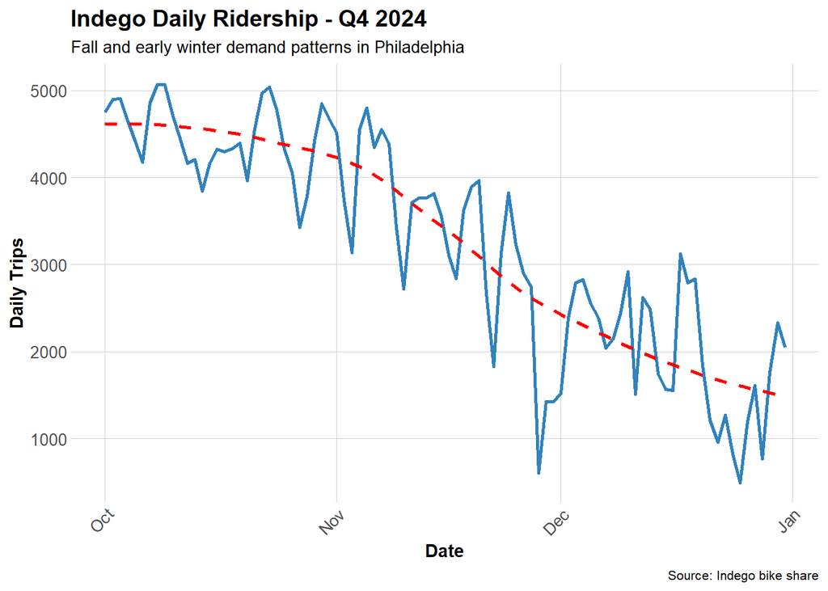

```r
# Daily trip counts
daily_trips <- indego %>%
  group_by(date) %>%
  summarize(trips = n())

ggplot(daily_trips, aes(x = date, y = trips)) +
  geom_line(color = "#3182bd", linewidth = 1) +
  geom_smooth(se = FALSE, color = "red", linetype = "dashed") +
  labs(
    title = "Indego Daily Ridership - Q4 2024",
    subtitle = "Fall and early winter demand patterns in Philadelphia",
    x = "Date",
    y = "Daily Trips",
    caption = "Source: Indego bike share"
  ) +
  plotTheme
```

**Interpretation:**

Over Q4 2024, daily Indego ridership shows a clear downward tren, which is total opposite compared to the pattern of Q1 2025.On top of this overall decline there is a strong weekly pattern, with repeated peaks and dips that likely reflect higher weekday commuting demand and lower weekend ridership. There are also a few sharp drops later in the quarter, which could correspond to holidays or especially bad‐weather days.

### Hourly Patterns

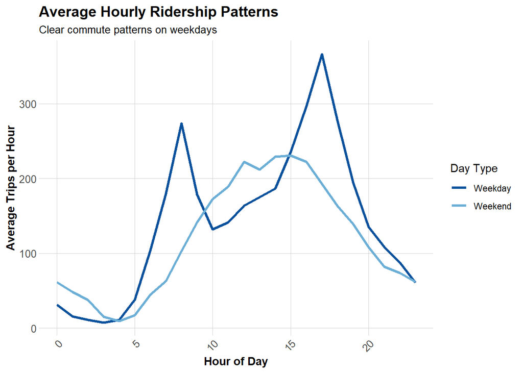

```r
# Average trips by hour and day type
hourly_patterns <- indego %>%
  group_by(hour, weekend) %>%
  summarize(avg_trips = n() / n_distinct(date)) %>%
  mutate(day_type = ifelse(weekend == 1, "Weekend", "Weekday"))

ggplot(hourly_patterns, aes(x = hour, y = avg_trips, color = day_type)) +
  geom_line(linewidth = 1.2) +
  scale_color_manual(values = c("Weekday" = "#08519c", "Weekend" = "#6baed6")) +
  labs(
    title = "Average Hourly Ridership Patterns",
    subtitle = "Clear commute patterns on weekdays",
    x = "Hour of Day",
    y = "Average Trips per Hour",
    color = "Day Type"
  ) +
  plotTheme
```

**Interpretation:**

Compared to Q1 2025, the whole pattern are similar but the largest number of Q4 2024 is higher than that one by nearly 70 trips per hour.

### Top Stations

```r
# Most popular origin stations
top_stations <- indego %>%
  count(start_station, start_lat, start_lon, name = "trips") %>%
  arrange(desc(trips)) %>%
  head(20)

kable(top_stations,
      caption = "Top 20 Indego Stations by Trip Origins",
      format.args = list(big.mark = ",")) %>%
  kable_styling(bootstrap_options = c("striped", "hover"))
```

Top 20 Indego Stations by Trip Origins

| start_station | start_lat | start_lon | trips |
| --- | --- | --- | --- |
| 3,010 | 39.94711 | -75.16618 | 5,943 |
| 3,032 | 39.94527 | -75.17971 | 4,471 |
| 3,359 | 39.94888 | -75.16978 | 3,923 |
| 3,244 | 39.93865 | -75.16674 | 3,492 |
| 3,295 | 39.95028 | -75.16027 | 3,411 |
| 3,020 | 39.94855 | -75.19007 | 3,369 |
| 3,208 | 39.95048 | -75.19324 | 3,343 |
| 3,066 | 39.94561 | -75.17348 | 3,342 |
| 3,054 | 39.96250 | -75.17420 | 3,297 |
| 3,101 | 39.94295 | -75.15955 | 3,214 |
| 3,022 | 39.95472 | -75.18323 | 3,152 |
| 3,028 | 39.94061 | -75.14958 | 3,101 |
| 3,362 | 39.94816 | -75.16226 | 3,072 |
| 3,063 | 39.94633 | -75.16980 | 2,972 |
| 3,185 | 39.95169 | -75.15888 | 2,952 |
| 3,059 | 39.96244 | -75.16121 | 2,926 |
| 3,012 | 39.94218 | -75.17747 | 2,907 |
| 3,061 | 39.95425 | -75.17761 | 2,847 |
| 3,161 | 39.95486 | -75.18091 | 2,837 |
| 3,256 | 39.95269 | -75.17779 | 2,816 |

## 1.3 Philadelphia Spatial Context & Demographics

### Load Philadelphia Census Data

We’ll get census tract data to add demographic context to our stations.

```r
# Get Philadelphia census tracts
philly_census <- get_acs(
  geography = "tract",
  variables = c(
    "B01003_001",  # Total population
    "B19013_001",  # Median household income
    "B08301_001",  # Total commuters
    "B08301_010",  # Commute by transit
    "B02001_002",  # White alone
    "B25077_001"   # Median home value
  ),
  state = "PA",
  county = "Philadelphia",
  year = 2022,
  geometry = TRUE,
  output = "wide"
) %>%
  rename(
    Total_Pop = B01003_001E,
    Med_Inc = B19013_001E,
    Total_Commuters = B08301_001E,
    Transit_Commuters = B08301_010E,
    White_Pop = B02001_002E,
    Med_Home_Value = B25077_001E
  ) %>%
  mutate(
    Percent_Taking_Transit = (Transit_Commuters / Total_Commuters) * 100,
    Percent_White = (White_Pop / Total_Pop) * 100
  ) %>%
  st_transform(crs = 4326)  # WGS84 for lat/lon matching
# Check the data
glimpse(philly_census)
```

```
Rows: 408
Columns: 17
$ GEOID                  <chr> "42101001500", "42101001800", "42101002802", "4…
$ NAME                   <chr> "Census Tract 15; Philadelphia County; Pennsylv…
$ Total_Pop              <dbl> 3251, 3300, 5720, 4029, 4415, 1815, 3374, 2729,…
$ B01003_001M            <dbl> 677, 369, 796, 437, 853, 210, 480, 734, 763, 11…
$ Med_Inc                <dbl> 110859, 114063, 78871, 61583, 32347, 48581, 597…
$ B19013_001M            <dbl> 24975, 30714, 20396, 22293, 4840, 13812, 6278, …
$ Total_Commuters        <dbl> 2073, 2255, 3032, 2326, 1980, 969, 2427, 708, 2…
$ B08301_001M            <dbl> 387, 308, 478, 383, 456, 189, 380, 281, 456, 68…
$ Transit_Commuters      <dbl> 429, 123, 685, 506, 534, 192, 658, 218, 438, 51…
$ B08301_010M            <dbl> 188, 66, 219, 144, 285, 71, 278, 184, 176, 235,…
$ White_Pop              <dbl> 2185, 2494, 3691, 3223, 182, 984, 2111, 231, 35…
$ B02001_002M            <dbl> 268, 381, 592, 380, 88, 190, 463, 112, 238, 778…
$ Med_Home_Value         <dbl> 568300, 605000, 350600, 296400, 76600, 289700, …
$ B25077_001M            <dbl> 58894, 34876, 12572, 22333, 10843, 118720, 1506…
$ geometry               <MULTIPOLYGON [°]> MULTIPOLYGON (((-75.16558 3..., MU…
$ Percent_Taking_Transit <dbl> 20.694645, 5.454545, 22.592348, 21.754084, 26.9…
$ Percent_White          <dbl> 67.2100892, 75.5757576, 64.5279720, 79.9950360,…
```

### Map Philadelphia Context

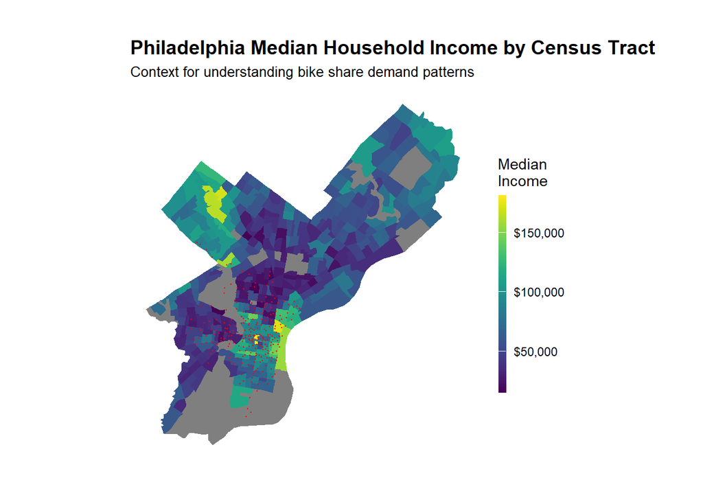

```r
# Map median income
ggplot() +
  geom_sf(data = philly_census, aes(fill = Med_Inc), color = NA) +
  scale_fill_viridis(
    option = "viridis",
    name = "Median\nIncome",
    labels = scales::dollar
  ) +
  labs(
    title = "Philadelphia Median Household Income by Census Tract",
    subtitle = "Context for understanding bike share demand patterns"
  ) +
  # Stations
  geom_point(
    data = indego,
    aes(x = start_lon, y = start_lat),
    color = "red", size = 0.25, alpha = 0.6
  ) +
  mapTheme
```

### Join Census Data to Stations

We’ll spatially join census characteristics to each bike station.

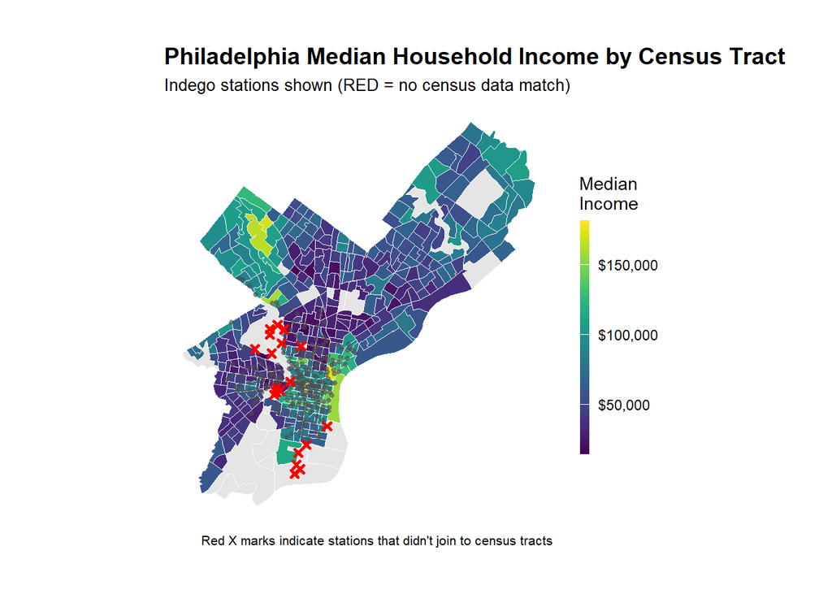

```r
# Create sf object for stations
stations_sf <- indego %>%
  distinct(start_station, start_lat, start_lon) %>%
  filter(!is.na(start_lat), !is.na(start_lon)) %>%
  st_as_sf(coords = c("start_lon", "start_lat"), crs = 4326)

# Spatial join to get census tract for each station
stations_census <- st_join(stations_sf, philly_census, left = TRUE) %>%
  st_drop_geometry()

# Look at the result - investigate whether all of the stations joined to census data -- according to the map above there are stations in non-residential tracts.

stations_for_map <- indego %>%
  distinct(start_station, start_lat, start_lon) %>%
  filter(!is.na(start_lat), !is.na(start_lon)) %>%
  left_join(
    stations_census %>% select(start_station, Med_Inc),
    by = "start_station"
  ) %>%
  mutate(has_census = !is.na(Med_Inc))

# Add back to trip data
indego_census <- indego %>%
  left_join(
    stations_census %>%
      select(start_station, Med_Inc, Percent_Taking_Transit,
             Percent_White, Total_Pop),
    by = "start_station"
  )


# Prepare data for visualization
stations_for_map <- indego %>%
  distinct(start_station, start_lat, start_lon) %>%
  filter(!is.na(start_lat), !is.na(start_lon)) %>%
  left_join(
    stations_census %>% select(start_station, Med_Inc),
    by = "start_station"
  ) %>%
  mutate(has_census = !is.na(Med_Inc))

# Create the map showing problem stations
ggplot() +
  geom_sf(data = philly_census, aes(fill = Med_Inc), color = "white", size = 0.1) +
  scale_fill_viridis(
    option = "viridis",
    name = "Median\nIncome",
    labels = scales::dollar,
    na.value = "grey90"
  ) +
  # Stations with census data (small grey dots)
  geom_point(
    data = stations_for_map %>% filter(has_census),
    aes(x = start_lon, y = start_lat),
    color = "grey30", size = 1, alpha = 0.6
  ) +
  # Stations WITHOUT census data (red X marks the spot)
  geom_point(
    data = stations_for_map %>% filter(!has_census),
    aes(x = start_lon, y = start_lat),
    color = "red", size = 1, shape = 4, stroke = 1.5
  ) +
  labs(
    title = "Philadelphia Median Household Income by Census Tract",
    subtitle = "Indego stations shown (RED = no census data match)",
    caption = "Red X marks indicate stations that didn't join to census tracts"
  ) +
  mapTheme
```

### Dealing with missing data

We need to decide what to do with the non-residential bike share stations. For this example, we are going to remove them – this is not necessarily the right way to do things always, but for the sake of simplicity, we are narrowing our scope to only stations in residential neighborhoods. We might opt to create a separate model for non-residential stations.

```r
# Identify which stations to keep
valid_stations <- stations_census %>%
  filter(!is.na(Med_Inc)) %>%
  pull(start_station)

# Filter trip data to valid stations only
indego_census <- indego %>%
  filter(start_station %in% valid_stations) %>%
  left_join(
    stations_census %>%
      select(start_station, Med_Inc, Percent_Taking_Transit,
             Percent_White, Total_Pop),
    by = "start_station"
  )
```

## 1.4 Weather Data

### Get Weather Data

Weather significantly affects bike share demand! Let’s get hourly weather for Philadelphia.

```r
# Get weather from Philadelphia International Airport (KPHL)
# This covers Q4 2024: Oct 1 - Dec 31
weather_data <- riem_measures(
  station = "PHL",  # Philadelphia International Airport
  date_start = "2024-10-01",
  date_end = "2024-12-31"
)

# Process weather data
weather_processed <- weather_data %>%
  mutate(
    interval60 = floor_date(valid, unit = "hour"),
    Temperature = tmpf,  # Temperature in Fahrenheit
    Precipitation = ifelse(is.na(p01i), 0, p01i),  # Hourly precip in inches
    Wind_Speed = sknt  # Wind speed in knots
  ) %>%
  select(interval60, Temperature, Precipitation, Wind_Speed) %>%
  distinct()

# Check for missing hours and interpolate if needed
weather_complete <- weather_processed %>%
  complete(interval60 = seq(min(interval60), max(interval60), by = "hour")) %>%
  fill(Temperature, Precipitation, Wind_Speed, .direction = "down")

# Look at the weather
summary(weather_complete %>% select(Temperature, Precipitation, Wind_Speed))
```

```
  Temperature    Precipitation        Wind_Speed
 Min.   :12.00   Min.   :0.000000   Min.   : 0.000
 1st Qu.:41.00   1st Qu.:0.000000   1st Qu.: 4.000
 Median :51.00   Median :0.000000   Median : 7.000
 Mean   :50.80   Mean   :0.004177   Mean   : 7.663
 3rd Qu.:60.95   3rd Qu.:0.000000   3rd Qu.:11.000
 Max.   :83.00   Max.   :0.520000   Max.   :30.000
```

### Visualize Weather Patterns

Who is ready for a Philly fall and early winter?!

[figure not shown]

```r
ggplot(weather_complete, aes(x = interval60, y = Temperature)) +
  geom_line(color = "#3182bd", alpha = 0.7) +
  geom_smooth(se = FALSE, color = "red") +
  labs(
    title = "Philadelphia Temperature - Q4 2024",
    subtitle = "Winter to early spring transition",
    x = "Date",
    y = "Temperature (°F)"
  ) +
  plotTheme
```

**Interpretation**:

The trend of temperature for Q4 2024 is decreasing, while it shows a fluctuation during the last month.

## 1.5 Create Space–Time Panel

### Aggregate Trips to Station-Hour Level

```r
# Count trips by station-hour
trips_panel <- indego_census %>%
  group_by(interval60, start_station, start_lat, start_lon,
           Med_Inc, Percent_Taking_Transit, Percent_White, Total_Pop) %>%
  summarize(Trip_Count = n()) %>%
  ungroup()

# How many station-hour observations?
nrow(trips_panel)
```

```
[1] 150972
```

```r
# How many unique stations?
length(unique(trips_panel$start_station))
```

```
[1] 237
```

```r
# How many unique hours?
length(unique(trips_panel$interval60))
```

```
[1] 2208
```

### Create Complete Panel Structure

Not every station has trips every hour. We need a **complete panel** where every station-hour combination exists (even if Trip_Count = 0).

```r
# Calculate expected panel size
n_stations <- length(unique(trips_panel$start_station))
n_hours <- length(unique(trips_panel$interval60))
expected_rows <- n_stations * n_hours

cat("Expected panel rows:", format(expected_rows, big.mark = ","), "\n")
```

```
Expected panel rows: 523,296
```

```r
cat("Current rows:", format(nrow(trips_panel), big.mark = ","), "\n")
```

```
Current rows: 150,972
```

```r
cat("Missing rows:", format(expected_rows - nrow(trips_panel), big.mark = ","), "\n")
```

```
Missing rows: 372,324
```

```r
# Create complete panel
study_panel <- expand.grid(
  interval60 = unique(trips_panel$interval60),
  start_station = unique(trips_panel$start_station)
) %>%
  # Join trip counts
  left_join(trips_panel, by = c("interval60", "start_station")) %>%
  # Replace NA trip counts with 0
  mutate(Trip_Count = replace_na(Trip_Count, 0))

# Fill in station attributes (they're the same for all hours)
station_attributes <- trips_panel %>%
  group_by(start_station) %>%
  summarize(
    start_lat = first(start_lat),
    start_lon = first(start_lon),
    Med_Inc = first(Med_Inc),
    Percent_Taking_Transit = first(Percent_Taking_Transit),
    Percent_White = first(Percent_White),
    Total_Pop = first(Total_Pop)
  )

study_panel <- study_panel %>%
  left_join(station_attributes, by = "start_station")

# Verify we have complete panel
cat("Complete panel rows:", format(nrow(study_panel), big.mark = ","), "\n")
```

```
Complete panel rows: 523,296
```

### Add Time Features

```r
study_panel <- study_panel %>%
  mutate(
    week = week(interval60),
    month = month(interval60, label = TRUE),
    dotw = wday(interval60, label = TRUE),
    hour = hour(interval60),
    date = as.Date(interval60),
    weekend = ifelse(dotw %in% c("Sat", "Sun"), 1, 0),
    rush_hour = ifelse(hour %in% c(7, 8, 9, 16, 17, 18), 1, 0)
  )
```

### Join Weather Data

```r
study_panel <- study_panel %>%
  left_join(weather_complete, by = "interval60")

# Check for missing values
summary(study_panel %>% select(Trip_Count, Temperature, Precipitation))
```

```
   Trip_Count       Temperature   Precipitation
 Min.   : 0.0000   Min.   :12.0   Min.   :0.0000
 1st Qu.: 0.0000   1st Qu.:41.0   1st Qu.:0.0000
 Median : 0.0000   Median :51.0   Median :0.0000
 Mean   : 0.5178   Mean   :50.8   Mean   :0.0042
 3rd Qu.: 1.0000   3rd Qu.:61.0   3rd Qu.:0.0000
 Max.   :28.0000   Max.   :83.0   Max.   :0.5200
                   NA's   :5688   NA's   :5688
```

## 1.6 Temporal Lag Features & Train/Test Split

### Create Temporal Lag Variables

The key innovation for space-time prediction: **past demand predicts future demand**.

### Why Lags?

If there were 15 bike trips from Station A at 8:00 AM, there will probably be ~15 trips at 9:00 AM. We can use this temporal persistence to improve predictions.

```r
# Sort by station and time
study_panel <- study_panel %>%
  arrange(start_station, interval60)

# Create lag variables WITHIN each station
study_panel <- study_panel %>%
  group_by(start_station) %>%
  mutate(
    lag1Hour = lag(Trip_Count, 1),
    lag2Hours = lag(Trip_Count, 2),
    lag3Hours = lag(Trip_Count, 3),
    lag12Hours = lag(Trip_Count, 12),
    lag1day = lag(Trip_Count, 24)
  ) %>%
  ungroup()

# Remove rows with NA lags (first 24 hours for each station)
study_panel_complete <- study_panel %>%
  filter(!is.na(lag1day))

cat("Rows after removing NA lags:", format(nrow(study_panel_complete), big.mark = ","), "\n")
```

```
Rows after removing NA lags: 605,298
```

### Visualize Lag Correlations

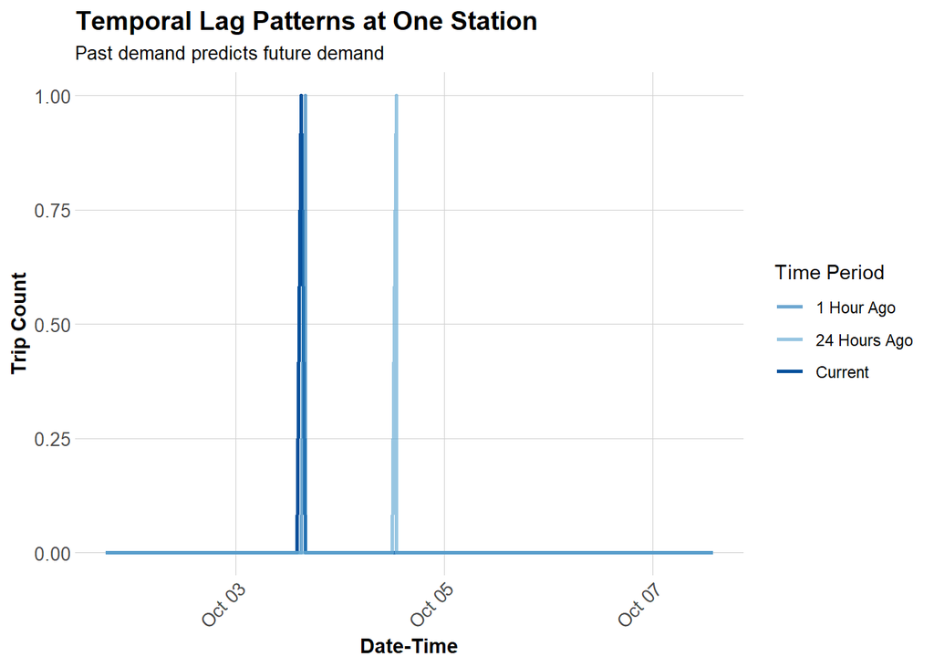

```r
# Sample one station to visualize
# Sample one station to visualize
example_station <- study_panel_complete %>%
  filter(start_station == first(start_station)) %>%
  head(168)  # One week

# Plot actual vs lagged demand
ggplot(example_station, aes(x = interval60)) +
  geom_line(aes(y = Trip_Count, color = "Current"), linewidth = 1) +
  geom_line(aes(y = lag1Hour, color = "1 Hour Ago"), linewidth = 1, alpha = 0.7) +
  geom_line(aes(y = lag1day, color = "24 Hours Ago"), linewidth = 1, alpha = 0.7) +
  scale_color_manual(values = c(
    "Current" = "#08519c",
    "1 Hour Ago" = "#3182bd",
    "24 Hours Ago" = "#6baed6"
  )) +
  labs(
    title = "Temporal Lag Patterns at One Station",
    subtitle = "Past demand predicts future demand",
    x = "Date-Time",
    y = "Trip Count",
    color = "Time Period"
  ) +
  plotTheme
```

### Temporal Train/Test Split

**CRITICAL:** We must train on PAST data and test on FUTURE data!

### Why Temporal Validation Matters

In real operations, at 6:00 AM on March 15, we need to predict demand for March 15-31. We have data from Jan 1 - March 14, but NOT from March 15-31 (it hasn’t happened yet!).

**Wrong approach:** Train on weeks 10-13, test on weeks 1-9 (predicting past from future!)

```r
# Split by week
# Q4 has weeks 40-53 (Oct-Dec)
# Train on weeks 40-49 (Jan 1 - early Dec)
# Test on weeks 50-53 (rest of Dec)

# Which stations have trips in BOTH early and late periods?
early_stations <- study_panel_complete %>%
  filter(week < 50) %>%
  filter(Trip_Count > 0) %>%
  distinct(start_station) %>%
  pull(start_station)

late_stations <- study_panel_complete %>%
  filter(week >= 50) %>%
  filter(Trip_Count > 0) %>%
  distinct(start_station) %>%
  pull(start_station)

# Keep only stations that appear in BOTH periods
common_stations <- intersect(early_stations, late_stations)


# Filter panel to only common stations
study_panel_complete <- study_panel_complete %>%
  filter(start_station %in% common_stations)

# NOW create train/test split
train <- study_panel_complete %>%
  filter(week < 50)

test <- study_panel_complete %>%
  filter(week >= 50)

cat("Training observations:", format(nrow(train), big.mark = ","), "\n")
```

```
Training observations: 410,628
```

```r
cat("Testing observations:", format(nrow(test), big.mark = ","), "\n")
```

```
Testing observations: 171,684
```

```r
cat("Training date range:", min(train$date), "to", max(train$date), "\n")
```

```
Training date range: 19997 to 20065
```

```r
cat("Testing date range:", min(test$date), "to", max(test$date), "\n")
```

```
Testing date range: 20066 to 20088
```

## 1.7 Build & Compare Predictive Models

We’ll build 5 models with increasing complexity to see what improves predictions.

### Model 1: Baseline (Time + Weather)

```r
# Create day of week factor with treatment (dummy) coding
train <- train %>%
  mutate(dotw_simple = factor(dotw, levels = c("Mon", "Tue", "Wed", "Thu", "Fri", "Sat", "Sun")))

# Set contrasts to treatment coding (dummy variables)
contrasts(train$dotw_simple) <- contr.treatment(7)

# Now run the model
model1 <- lm(
  Trip_Count ~ as.factor(hour) + dotw_simple + Temperature + Precipitation,
  data = train
)

summary(model1)
```

```
Call:
lm(formula = Trip_Count ~ as.factor(hour) + dotw_simple + Temperature +
    Precipitation, data = train)

Residuals:
    Min      1Q  Median      3Q     Max
-1.7089 -0.6783 -0.2159  0.1882 27.2727

Coefficients:
                   Estimate Std. Error t value             Pr(>|t|)
(Intercept)       -0.489156   0.013731 -35.624 < 0.0000000000000002 ***
as.factor(hour)1  -0.055267   0.012906  -4.282   0.0000184994686084 ***
as.factor(hour)2  -0.078435   0.012690  -6.181   0.0000000006378151 ***
as.factor(hour)3  -0.110234   0.012655  -8.711 < 0.0000000000000002 ***
as.factor(hour)4  -0.074204   0.012566  -5.905   0.0000000035263476 ***
as.factor(hour)5   0.038930   0.012623   3.084             0.002042 **
as.factor(hour)6   0.296063   0.012639  23.424 < 0.0000000000000002 ***
as.factor(hour)7   0.562184   0.012853  43.738 < 0.0000000000000002 ***
as.factor(hour)8   0.940524   0.012603  74.629 < 0.0000000000000002 ***
as.factor(hour)9   0.681527   0.012691  53.700 < 0.0000000000000002 ***
as.factor(hour)10  0.562441   0.012526  44.900 < 0.0000000000000002 ***
as.factor(hour)11  0.602993   0.012538  48.094 < 0.0000000000000002 ***
as.factor(hour)12  0.698148   0.012435  56.145 < 0.0000000000000002 ***
as.factor(hour)13  0.667308   0.012338  54.085 < 0.0000000000000002 ***
as.factor(hour)14  0.685610   0.012386  55.355 < 0.0000000000000002 ***
as.factor(hour)15  0.791576   0.012780  61.940 < 0.0000000000000002 ***
as.factor(hour)16  0.906925   0.012549  72.273 < 0.0000000000000002 ***
as.factor(hour)17  1.110205   0.012639  87.842 < 0.0000000000000002 ***
as.factor(hour)18  0.831297   0.012728  65.314 < 0.0000000000000002 ***
as.factor(hour)19  0.541516   0.012768  42.412 < 0.0000000000000002 ***
as.factor(hour)20  0.341348   0.012858  26.547 < 0.0000000000000002 ***
as.factor(hour)21  0.233603   0.012881  18.135 < 0.0000000000000002 ***
as.factor(hour)22  0.175194   0.012820  13.666 < 0.0000000000000002 ***
as.factor(hour)23  0.076033   0.012906   5.891   0.0000000038337890 ***
dotw_simple2       0.065588   0.006869   9.549 < 0.0000000000000002 ***
dotw_simple3       0.062920   0.006857   9.177 < 0.0000000000000002 ***
dotw_simple4      -0.050061   0.006571  -7.619   0.0000000000000257 ***
dotw_simple5      -0.012223   0.006833  -1.789             0.073612 .
dotw_simple6      -0.024444   0.006806  -3.591             0.000329 ***
dotw_simple7      -0.050983   0.006924  -7.363   0.0000000000001797 ***
Temperature        0.012467   0.000161  77.432 < 0.0000000000000002 ***
Precipitation     -1.109233   0.081793 -13.562 < 0.0000000000000002 ***
---
Signif. codes:  0 '***' 0.001 '**' 0.01 '*' 0.05 '.' 0.1 ' ' 1

Residual standard error: 1.144 on 410596 degrees of freedom
Multiple R-squared:  0.1141,    Adjusted R-squared:  0.114
F-statistic:  1705 on 31 and 410596 DF,  p-value: < 0.00000000000000022
```

**Interpretation**

The table shows the results of an OLS regression explaining hourly trip counts using hour-of-day dummies, simplified day-of-week indicators, temperature and precipitation, with the overall model highly significant (F-test p < 0.001) but a modest explanatory power (R² ≈ 0.11). Most daytime hours and higher temperatures are associated with significantly more trips, while precipitation has a large, negative and highly significant effect on ridership.

### Model 2: Add Temporal Lags

```r
model2 <- lm(
  Trip_Count ~ as.factor(hour) + dotw_simple + Temperature + Precipitation +
    lag1Hour + lag3Hours + lag1day,
  data = train
)

summary(model2)
```

```
Call:
lm(formula = Trip_Count ~ as.factor(hour) + dotw_simple + Temperature +
    Precipitation + lag1Hour + lag3Hours + lag1day, data = train)

Residuals:
     Min       1Q   Median       3Q      Max
-12.8428  -0.4697  -0.1265   0.1225  25.5313

Coefficients:
                    Estimate Std. Error t value             Pr(>|t|)
(Intercept)       -0.1971724  0.0120171 -16.408 < 0.0000000000000002 ***
as.factor(hour)1  -0.0175731  0.0112639  -1.560              0.11873
as.factor(hour)2  -0.0093400  0.0110785  -0.843              0.39918
as.factor(hour)3  -0.0323163  0.0110523  -2.924              0.00346 **
as.factor(hour)4  -0.0064036  0.0109793  -0.583              0.55973
as.factor(hour)5   0.0625618  0.0110386   5.668  0.00000001449553616 ***
as.factor(hour)6   0.2581886  0.0110639  23.336 < 0.0000000000000002 ***
as.factor(hour)7   0.4087297  0.0112659  36.280 < 0.0000000000000002 ***
as.factor(hour)8   0.6475387  0.0110725  58.482 < 0.0000000000000002 ***
as.factor(hour)9   0.2687374  0.0111533  24.095 < 0.0000000000000002 ***
as.factor(hour)10  0.2122365  0.0109778  19.333 < 0.0000000000000002 ***
as.factor(hour)11  0.2554385  0.0109944  23.234 < 0.0000000000000002 ***
as.factor(hour)12  0.3583675  0.0108988  32.881 < 0.0000000000000002 ***
as.factor(hour)13  0.3239304  0.0108163  29.948 < 0.0000000000000002 ***
as.factor(hour)14  0.3531805  0.0108536  32.540 < 0.0000000000000002 ***
as.factor(hour)15  0.4322898  0.0112024  38.589 < 0.0000000000000002 ***
as.factor(hour)16  0.5127136  0.0110123  46.558 < 0.0000000000000002 ***
as.factor(hour)17  0.6404994  0.0111130  57.635 < 0.0000000000000002 ***
as.factor(hour)18  0.3266069  0.0112005  29.160 < 0.0000000000000002 ***
as.factor(hour)19  0.1612724  0.0111995  14.400 < 0.0000000000000002 ***
as.factor(hour)20  0.0449273  0.0112804   3.983  0.00006812693842302 ***
as.factor(hour)21  0.0488508  0.0112677   4.335  0.00001454699054148 ***
as.factor(hour)22  0.0606778  0.0111954   5.420  0.00000005967221309 ***
as.factor(hour)23  0.0183651  0.0112646   1.630              0.10303
dotw_simple2       0.0070021  0.0059975   1.167              0.24301
dotw_simple3      -0.0128484  0.0059925  -2.144              0.03203 *
dotw_simple4      -0.0448243  0.0057357  -7.815  0.00000000000000551 ***
dotw_simple5      -0.0422563  0.0059684  -7.080  0.00000000000144379 ***
dotw_simple6      -0.0367596  0.0059417  -6.187  0.00000000061504630 ***
dotw_simple7      -0.0593011  0.0060464  -9.808 < 0.0000000000000002 ***
Temperature        0.0040641  0.0001426  28.494 < 0.0000000000000002 ***
Precipitation     -0.9676346  0.0714492 -13.543 < 0.0000000000000002 ***
lag1Hour           0.3238000  0.0014825 218.412 < 0.0000000000000002 ***
lag3Hours          0.1180469  0.0014504  81.387 < 0.0000000000000002 ***
lag1day            0.2027487  0.0013895 145.912 < 0.0000000000000002 ***
---
Signif. codes:  0 '***' 0.001 '**' 0.01 '*' 0.05 '.' 0.1 ' ' 1

Residual standard error: 0.9988 on 410593 degrees of freedom
Multiple R-squared:  0.3252,    Adjusted R-squared:  0.3252
F-statistic:  5821 on 34 and 410593 DF,  p-value: < 0.00000000000000022
```

**Interpretation**

### Model 3: Add Demographics

```r
model3 <- lm(
  Trip_Count ~ as.factor(hour) + dotw_simple + Temperature + Precipitation +
    lag1Hour + lag3Hours + lag1day +
    Med_Inc.x + Percent_Taking_Transit.y + Percent_White.y,
  data = train
)

summary(model3)
```

```
Call:
lm(formula = Trip_Count ~ as.factor(hour) + dotw_simple + Temperature +
    Precipitation + lag1Hour + lag3Hours + lag1day + Med_Inc.x +
    Percent_Taking_Transit.y + Percent_White.y, data = train)

Residuals:
     Min       1Q   Median       3Q      Max
-10.2603  -0.7198  -0.2719   0.4456  24.6278

Coefficients:
                              Estimate    Std. Error t value
(Intercept)               0.7009115282  0.0386608126  18.130
as.factor(hour)1         -0.0339064631  0.0443755122  -0.764
as.factor(hour)2         -0.0733390073  0.0472207425  -1.553
as.factor(hour)3         -0.1736198797  0.0563179188  -3.083
as.factor(hour)4         -0.1602016516  0.0526556216  -3.042
as.factor(hour)5         -0.0842198175  0.0392042217  -2.148
as.factor(hour)6          0.1812725910  0.0339389718   5.341
as.factor(hour)7          0.3659932453  0.0327798040  11.165
as.factor(hour)8          0.6419351722  0.0315874296  20.322
as.factor(hour)9          0.0689540443  0.0318174207   2.167
as.factor(hour)10         0.0455849373  0.0318601406   1.431
as.factor(hour)11         0.0951277607  0.0317831322   2.993
as.factor(hour)12         0.1718233329  0.0312986651   5.490
as.factor(hour)13         0.1501299648  0.0313008986   4.796
as.factor(hour)14         0.1546199385  0.0311814820   4.959
as.factor(hour)15         0.2738677333  0.0314129060   8.718
as.factor(hour)16         0.3825663042  0.0310863390  12.307
as.factor(hour)17         0.5958195674  0.0311303049  19.140
as.factor(hour)18         0.1871034280  0.0314626011   5.947
as.factor(hour)19         0.0105635560  0.0320040115   0.330
as.factor(hour)20        -0.0963042374  0.0327876103  -2.937
as.factor(hour)21        -0.0718694380  0.0336061149  -2.139
as.factor(hour)22        -0.0356940800  0.0343008260  -1.041
as.factor(hour)23        -0.0793554621  0.0360569574  -2.201
dotw_simple2              0.0015399442  0.0129720488   0.119
dotw_simple3             -0.0058302798  0.0131356919  -0.444
dotw_simple4             -0.0584003672  0.0128820191  -4.533
dotw_simple5             -0.0902616975  0.0132777688  -6.798
dotw_simple6             -0.0296928615  0.0133240066  -2.229
```

[output cut: 40 more lines]

```
Temperature              < 0.0000000000000002 ***
Precipitation            < 0.0000000000000002 ***
lag1Hour                 < 0.0000000000000002 ***
lag3Hours                < 0.0000000000000002 ***
lag1day                  < 0.0000000000000002 ***
Med_Inc.x                             0.12579
Percent_Taking_Transit.y < 0.0000000000000002 ***
Percent_White.y          < 0.0000000000000002 ***
---
Signif. codes:  0 '***' 0.001 '**' 0.01 '*' 0.05 '.' 0.1 ' ' 1

Residual standard error: 1.274 on 133822 degrees of freedom
  (276768 observations deleted due to missingness)
Multiple R-squared:  0.2192,    Adjusted R-squared:  0.219
F-statistic:  1015 on 37 and 133822 DF,  p-value: < 0.00000000000000022
```

### Model 4: Add Station Fixed Effects

```r
model4 <- lm(
  Trip_Count ~ as.factor(hour) + dotw_simple + Temperature + Precipitation +
    lag1Hour + lag3Hours + lag1day +
    Med_Inc.x + Percent_Taking_Transit.y + Percent_White.y +
    as.factor(start_station),
  data = train
)

# Summary too long with all station dummies, just show key metrics
cat("Model 4 R-squared:", summary(model4)$r.squared, "\n")
```

```
Model 4 R-squared: 0.2469249
```

```r
cat("Model 4 Adj R-squared:", summary(model4)$adj.r.squared, "\n")
```

```
Model 4 Adj R-squared: 0.2454536
```

**Interpretation**

Comparing Model 3 and Model 4, adding station fixed effects raises the R-squared from about 0.22 to 0.25, meaning the model explains more of the variation in trips once these dummies are included. This shows that station fixed effects are capturing systematic baseline differences in demand across stations—some locations are consistently busier or quieter than others, even after controlling for time, weather, and lagged ridership.

### Model 5: Add Rush Hour Interaction

```r
model5 <- lm(
  Trip_Count ~ as.factor(hour) + dotw_simple + Temperature + Precipitation +
    lag1Hour + lag3Hours + lag1day + rush_hour + as.factor(month) +
    Med_Inc.x + Percent_Taking_Transit.y + Percent_White.y +
    as.factor(start_station) +
    rush_hour * weekend,  # Rush hour effects different on weekends
  data = train
)

cat("Model 5 R-squared:", summary(model5)$r.squared, "\n")
```

```
Model 5 R-squared: 0.2526638
```

```r
cat("Model 5 Adj R-squared:", summary(model5)$adj.r.squared, "\n")
```

```
Model 5 Adj R-squared: 0.251187
```

**Interpretation**

In Model 5, after adding the extra explanatory variables, the R-squared increases from about 0.247 to 0.253 and the adjusted R-squared also rises slightly, indicating that the upgraded specification captures a bit more of the variation in trip counts without obvious overfitting.

## 1.8 Model Evaluation & Q1 2025 Comparison

### Calculate Predictions and MAE

```r
# Get predictions on test set

# Create day of week factor with treatment (dummy) coding
test <- test %>%
  mutate(dotw_simple = factor(dotw, levels = c("Mon", "Tue", "Wed", "Thu", "Fri", "Sat", "Sun")))

# Set contrasts to treatment coding (dummy variables)
contrasts(test$dotw_simple) <- contr.treatment(7)

test <- test %>%
  mutate(
    pred1 = predict(model1, newdata = test),
    pred2 = predict(model2, newdata = test),
    pred3 = predict(model3, newdata = test),
    pred4 = predict(model4, newdata = test),
    pred5 = predict(model5, newdata = test)
  )

# Calculate MAE for each model
mae_results <- data.frame(
  Model = c(
    "1. Time + Weather",
    "2. + Temporal Lags",
    "3. + Demographics",
    "4. + Station FE",
    "5. + Rush Hour Interaction"
  ),
  MAE = c(
    mean(abs(test$Trip_Count - test$pred1), na.rm = TRUE),
    mean(abs(test$Trip_Count - test$pred2), na.rm = TRUE),
    mean(abs(test$Trip_Count - test$pred3), na.rm = TRUE),
    mean(abs(test$Trip_Count - test$pred4), na.rm = TRUE),
    mean(abs(test$Trip_Count - test$pred5), na.rm = TRUE)
  )
)

kable(mae_results,
      digits = 2,
      caption = "Mean Absolute Error by Model (Test Set)",
      col.names = c("Model", "MAE (trips)")) %>%
  kable_styling(bootstrap_options = c("striped", "hover"))
```

Mean Absolute Error by Model (Test Set)

| Model | MAE (trips) |
| --- | --- |
| 1. Time + Weather | 0.54 |
| 2. + Temporal Lags | 0.40 |
| 3. + Demographics | 0.64 |
| 4. + Station FE | 0.66 |
| 5. + Rush Hour Interaction | 0.65 |

**Interpretation**

Using test-set MAE to compare specifications, Model 2 (which adds temporal lags) performs best with the lowest error of 0.40 trips, while adding demographics, station fixed effects and rush-hour interactions in Models 3–5 actually increases MAE, suggesting that these extra terms do not improve – and may even hurt – out-of-sample predictive accuracy.

### Visualize Model Comparison

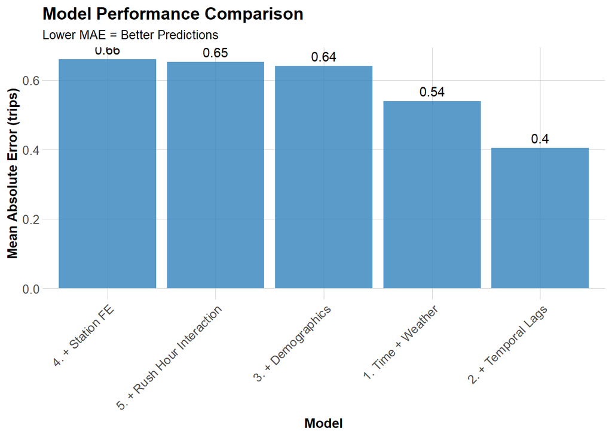

```r
ggplot(mae_results, aes(x = reorder(Model, -MAE), y = MAE)) +
  geom_col(fill = "#3182bd", alpha = 0.8) +
  geom_text(aes(label = round(MAE, 2)), vjust = -0.5) +
  labs(
    title = "Model Performance Comparison",
    subtitle = "Lower MAE = Better Predictions",
    x = "Model",
    y = "Mean Absolute Error (trips)"
  ) +
  plotTheme +
  theme(axis.text.x = element_text(angle = 45, hjust = 1))
```

**Interpretation**

From the chart, the largest improvement comes from adding temporal lags: moving from the “Time + Weather” model (MAE ≈ 0.54) to the “+ Temporal Lags” model (MAE ≈ 0.40) reduces the error by about 0.14 trips. By contrast, adding demographics, station fixed effects or rush-hour interactions actually increases MAE, so these features do not improve predictive accuracy.

### Compare Q4 2024 vs Q1 2025 (MAE & patterns)

1. How do the MAE values compare across quarters?

For every specification, MAE is higher in Q1 2025 than in Q4 2024 (e.g. the baseline “Time + Weather” model rises from 0.54 to 0.60, and the “+ Temporal Lags” model from 0.40 to 0.50), so the models predict less accurately in Q1.

2. Why might they differ?

This suggests that demand is more volatile or harder to explain in Q1 2025—possibly because of different seasonal conditions, holidays, or behavioural changes.

3. Are temporal patterns different?

The core commute-driven structure appears similar across quarters (with morning and evening peaks), but the higher MAE in Q1 implies that the exact timing and intensity of these peaks are less stable, making hour-by-hour trips more difficult to forecast.

4. Which features are most important in your quarter?

In both quarters, adding temporal lags delivers by far the largest reduction in MAE relative to the “Time + Weather” baseline, while adding demographics, station fixed effects, or rush-hour interactions actually increases MAE, so temporal lags are the most valuable features for prediction.

# Part 2: Error Analysis

## 2.1 Space–Time Error Analysis

### Observed vs. Predicted

Let’s use our best model (Model 2) for error analysis.

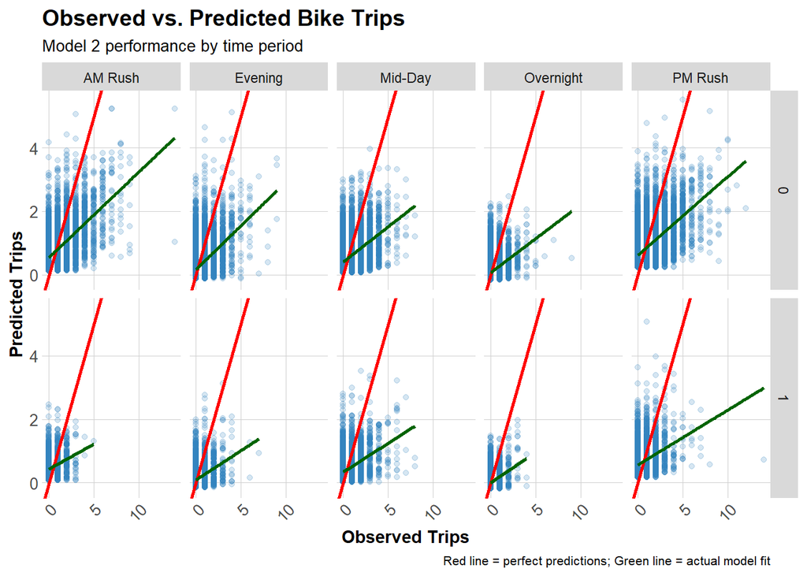

```r
test <- test %>%
  mutate(
    error = Trip_Count - pred2,
    abs_error = abs(error),
    time_of_day = case_when(
      hour < 7 ~ "Overnight",
      hour >= 7 & hour < 10 ~ "AM Rush",
      hour >= 10 & hour < 15 ~ "Mid-Day",
      hour >= 15 & hour <= 18 ~ "PM Rush",
      hour > 18 ~ "Evening"
    )
  )

# Scatter plot by time and day type
ggplot(test, aes(x = Trip_Count, y = pred2)) +
  geom_point(alpha = 0.2, color = "#3182bd") +
  geom_abline(slope = 1, intercept = 0, color = "red", linewidth = 1) +
  geom_smooth(method = "lm", se = FALSE, color = "darkgreen") +
  facet_grid(weekend ~ time_of_day) +
  labs(
    title = "Observed vs. Predicted Bike Trips",
    subtitle = "Model 2 performance by time period",
    x = "Observed Trips",
    y = "Predicted Trips",
    caption = "Red line = perfect predictions; Green line = actual model fit"
  ) +
  plotTheme
```

**Interpretation**

## 2.2 Spatial Error Patterns

### Spatial Error Patterns

Are prediction errors clustered in certain parts of Philadelphia?

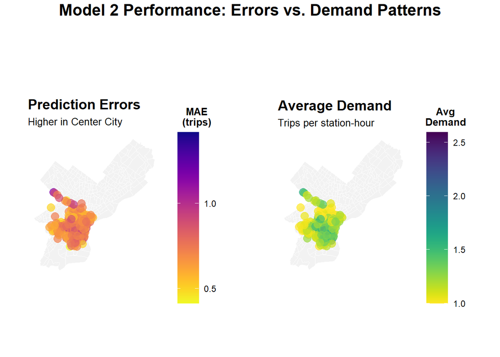

```r
# Calculate MAE by station
station_errors <- test %>%
  group_by(start_station, start_lat.x, start_lon.y) %>%
  summarize(
    MAE = mean(abs_error, na.rm = TRUE),
    avg_demand = mean(Trip_Count, na.rm = TRUE),
    .groups = "drop"
  ) %>%
  filter(!is.na(start_lat.x), !is.na(start_lon.y))

## Create Two Maps Side-by-Side with Proper Legends (sorry these maps are ugly)

# Calculate station errors
station_errors <- test %>%
  filter(!is.na(pred2)) %>%
  group_by(start_station, start_lat.x, start_lon.y) %>%
  summarize(
    MAE = mean(abs(Trip_Count - pred2), na.rm = TRUE),
    avg_demand = mean(Trip_Count, na.rm = TRUE),
    .groups = "drop"
  ) %>%
  filter(!is.na(start_lat.x), !is.na(start_lon.y))

# Map 1: Prediction Errors
p1 <- ggplot() +
  geom_sf(data = philly_census, fill = "grey95", color = "white", size = 0.2) +
  geom_point(
    data = station_errors,
    aes(x = start_lon.y, y = start_lat.x, color = MAE),
    size = 3.5,
    alpha = 0.7
  ) +
  scale_color_viridis(
    option = "plasma",
    name = "MAE\n(trips)",
    direction = -1,
    breaks = c(0.5, 1.0, 1.5),  # Fewer, cleaner breaks
    labels = c("0.5", "1.0", "1.5")
  ) +
  labs(title = "Prediction Errors",
       subtitle = "Higher in Center City") +
  mapTheme +
  theme(
    legend.position = "right",
    legend.title = element_text(size = 10, face = "bold"),
    legend.text = element_text(size = 9),
    plot.title = element_text(size = 14, face = "bold"),
    plot.subtitle = element_text(size = 10)
  ) +
  guides(color = guide_colorbar(
    barwidth = 1.5,
    barheight = 12,
    title.position = "top",
    title.hjust = 0.5
  ))

# Map 2: Average Demand
p2 <- ggplot() +
  geom_sf(data = philly_census, fill = "grey95", color = "white", size = 0.2) +
  geom_point(
    data = station_errors,
    aes(x = start_lon.y, y = start_lat.x, color = avg_demand),
    size = 3.5,
    alpha = 0.7
  ) +
  scale_color_viridis(
    option = "viridis",
    name = "Avg\nDemand",
    direction = -1,
    breaks = c(0.5, 1.0, 1.5, 2.0, 2.5),  # Clear breaks
    labels = c("0.5", "1.0", "1.5", "2.0", "2.5")
  ) +
  labs(title = "Average Demand",
       subtitle = "Trips per station-hour") +
  mapTheme +
  theme(
    legend.position = "right",
    legend.title = element_text(size = 10, face = "bold"),
    legend.text = element_text(size = 9),
    plot.title = element_text(size = 14, face = "bold"),
    plot.subtitle = element_text(size = 10)
  ) +
  guides(color = guide_colorbar(
    barwidth = 1.5,
    barheight = 12,
    title.position = "top",
    title.hjust = 0.5
  ))

# Combine with better layout
library(gridExtra)
library(grid)
grid.arrange(
  p1, p2,
  ncol = 2,
  top = textGrob(
    "Model 2 Performance: Errors vs. Demand Patterns",
    gp = gpar(fontsize = 16, fontface = "bold")
  )
)
```

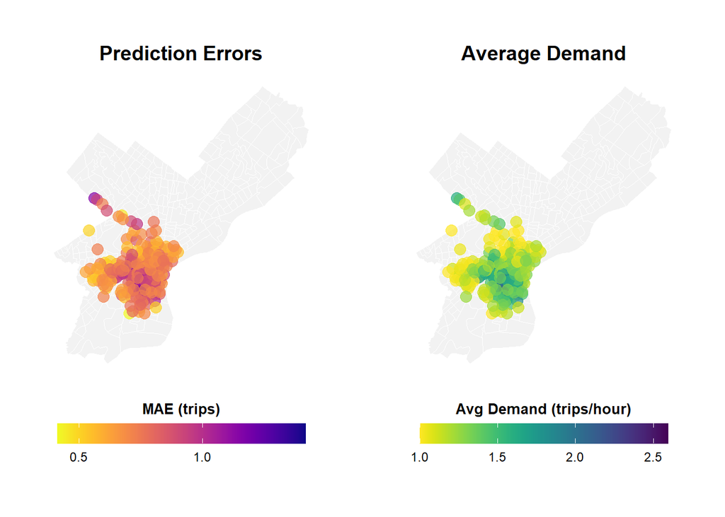

```r
# Map 1: Prediction Errors
p1 <- ggplot() +
  geom_sf(data = philly_census, fill = "grey95", color = "white", size = 0.1) +
  geom_point(
    data = station_errors,
    aes(x = start_lon.y, y = start_lat.x, color = MAE),
    size = 3.5,
    alpha = 0.7
  ) +
  scale_color_viridis(
    option = "plasma",
    name = "MAE (trips)",
    direction = -1,
    breaks = c(0.5, 1.0, 1.5),
    labels = c("0.5", "1.0", "1.5")
  ) +
  labs(title = "Prediction Errors") +
  mapTheme +
  theme(
    legend.position = "bottom",
    legend.title = element_text(size = 10, face = "bold"),
    legend.text = element_text(size = 9),
    plot.title = element_text(size = 14, face = "bold", hjust = 0.5)
  ) +
  guides(color = guide_colorbar(
    barwidth = 12,
    barheight = 1,
    title.position = "top",
    title.hjust = 0.5
  ))

# Map 2: Average Demand
p2 <- ggplot() +
  geom_sf(data = philly_census, fill = "grey95", color = "white", size = 0.1) +
  geom_point(
    data = station_errors,
    aes(x = start_lon.y, y = start_lat.x, color = avg_demand),
    size = 3.5,
    alpha = 0.7
  ) +
  scale_color_viridis(
    option = "viridis",
    name = "Avg Demand (trips/hour)",
    direction = -1,
    breaks = c(0.5, 1.0, 1.5, 2.0, 2.5),
    labels = c("0.5", "1.0", "1.5", "2.0", "2.5")
  ) +
  labs(title = "Average Demand") +
  mapTheme +
  theme(
    legend.position = "bottom",
    legend.title = element_text(size = 10, face = "bold"),
    legend.text = element_text(size = 9),
    plot.title = element_text(size = 14, face = "bold", hjust = 0.5)
  ) +
  guides(color = guide_colorbar(
    barwidth = 12,
    barheight = 1,
    title.position = "top",
    title.hjust = 0.5
  ))

# Combine
grid.arrange(
  p1, p2,
  ncol = 2
  )
```

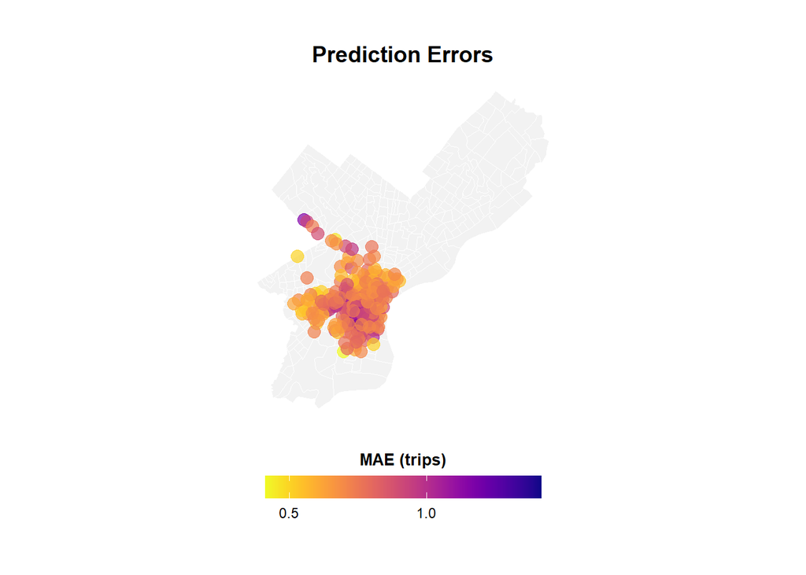

```r
p1
```

**Interpretation**

## 2.3 Temporal Error Patterns

### Temporal Error Patterns

When are we most wrong?

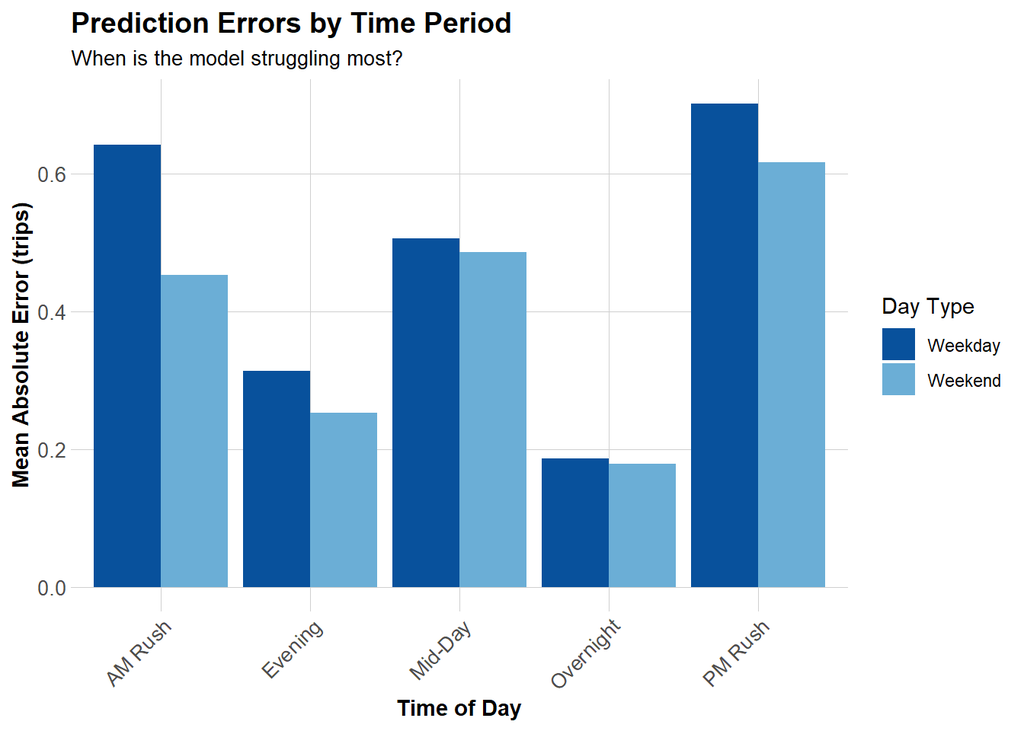

```r
# MAE by time of day and day type
temporal_errors <- test %>%
  group_by(time_of_day, weekend) %>%
  summarize(
    MAE = mean(abs_error, na.rm = TRUE),
    .groups = "drop"
  ) %>%
  mutate(day_type = ifelse(weekend == 1, "Weekend", "Weekday"))

ggplot(temporal_errors, aes(x = time_of_day, y = MAE, fill = day_type)) +
  geom_col(position = "dodge") +
  scale_fill_manual(values = c("Weekday" = "#08519c", "Weekend" = "#6baed6")) +
  labs(
    title = "Prediction Errors by Time Period",
    subtitle = "When is the model struggling most?",
    x = "Time of Day",
    y = "Mean Absolute Error (trips)",
    fill = "Day Type"
  ) +
  plotTheme +
  theme(axis.text.x = element_text(angle = 45, hjust = 1))
```

**Interpretation**

The chart shows that the model struggles most during the PM rush and AM rush, especially on weekdays, where mean absolute errors are the highest. Errors are moderate at mid-day and evening, and they are smallest overnight, indicating that off-peak demand is easier to predict than peak-hour commuting flows.

## 2.4 Errors and Demographics

### Errors and Demographics

Are prediction errors related to neighborhood characteristics?

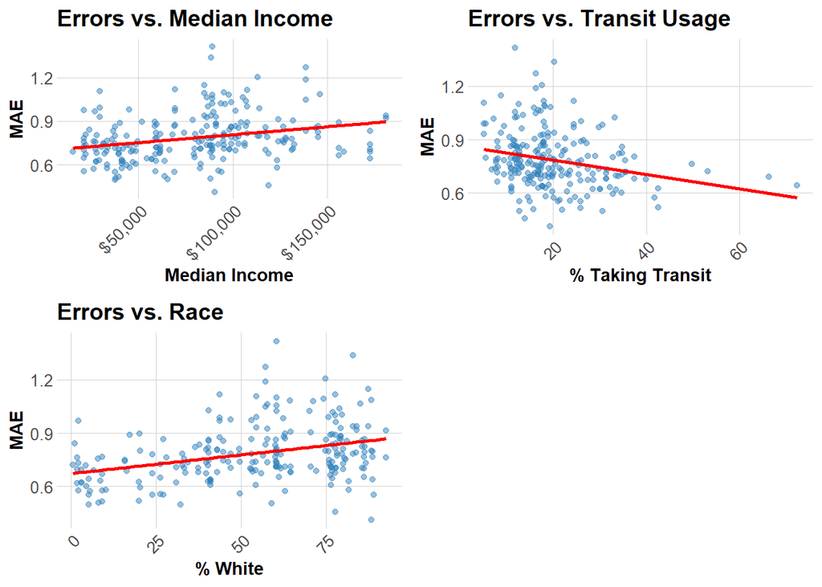

```r
# Join demographic data to station errors
station_errors_demo <- station_errors %>%
  left_join(
    station_attributes %>% select(start_station, Med_Inc, Percent_Taking_Transit, Percent_White),
    by = "start_station"
  ) %>%
  filter(!is.na(Med_Inc))

# Create plots
p1 <- ggplot(station_errors_demo, aes(x = Med_Inc, y = MAE)) +
  geom_point(alpha = 0.5, color = "#3182bd") +
  geom_smooth(method = "lm", se = FALSE, color = "red") +
  scale_x_continuous(labels = scales::dollar) +
  labs(title = "Errors vs. Median Income", x = "Median Income", y = "MAE") +
  plotTheme

p2 <- ggplot(station_errors_demo, aes(x = Percent_Taking_Transit, y = MAE)) +
  geom_point(alpha = 0.5, color = "#3182bd") +
  geom_smooth(method = "lm", se = FALSE, color = "red") +
  labs(title = "Errors vs. Transit Usage", x = "% Taking Transit", y = "MAE") +
  plotTheme

p3 <- ggplot(station_errors_demo, aes(x = Percent_White, y = MAE)) +
  geom_point(alpha = 0.5, color = "#3182bd") +
  geom_smooth(method = "lm", se = FALSE, color = "red") +
  labs(title = "Errors vs. Race", x = "% White", y = "MAE") +
  plotTheme

grid.arrange(p1, p2, p3, ncol = 2)
```

**Critical Question:**

The plots show slightly higher errors in richer, whiter areas and lower errors where more people use transit, so prediction accuracy is actually better in more transit-dependent, lower-income neighborhoods. This suggests no obvious equity harm in terms of error rates, though we should still monitor performance to keep accuracy similar across groups.

# Part 3: Feature Engineering & Model Improvement

## 3.1 New Features Motivated by Error Patterns

Error patterns from Part 2 suggest that the model struggles in three main situations:

To address these issues, I add three new features:

- **`is_holiday` (Temporal):** an indicator for major Q4 holidays (Halloween, Thanksgiving, Christmas, New Year’s Eve) when demand deviates sharply from normal patterns.
- **`weekend_good_weather` (Weather × Temporal):** an interaction capturing warm, dry weekend hours when leisure riding is especially high.
- **`dist_center_km` (Spatial):** the distance of each station from Center City (City Hall), approximating how “central” or “peripheral” a station is in the urban structure.

## 3.2 Implementing New Features

### code

```r
library(lubridate)
library(sf)
library(dplyr)

## 1) Holiday indicator: major Q4 holidays

study_panel_complete <- study_panel_complete %>%
  mutate(
    date = as.Date(interval60),
    is_holiday = ifelse(
      date %in% as.Date(c(
        "2024-10-31", # Halloween
        "2024-11-28", # Thanksgiving
        "2024-11-29", # Black Friday
        "2024-12-24", # Christmas Eve
        "2024-12-25", # Christmas Day
        "2024-12-31"  # New Year's Eve
      )),
      1, 0
    )
  )

## 2) Weekend × good weather interaction
# Define Q4 good weather
study_panel_complete <- study_panel_complete %>%
  mutate(
    good_weather = ifelse(
      Temperature >= 50 & Temperature <= 70 & Precipitation == 0,
      1, 0
    ),
    weekend_good_weather = weekend * good_weather
  )

## 3) Distance to Center City (City Hall) in km
study_panel_complete <- study_panel_complete %>%
  mutate(
    start_lat_all = coalesce(start_lat.x, start_lat.y),
    start_lon_all = coalesce(start_lon.x, start_lon.y)
  )

# transfer sf
stations_sf <- study_panel_complete %>%
  filter(!is.na(start_lat_all), !is.na(start_lon_all)) %>%
  distinct(start_station, start_lat_all, start_lon_all) %>%
  st_as_sf(coords = c("start_lon_all", "start_lat_all"), crs = 4326) %>%
  st_transform(26918)

# locate Center City
center_city <- st_sfc(
  st_point(c(-75.1636, 39.9526)),  # lon, lat of City Hall
  crs = 4326
) %>%
  st_transform(26918)

# Calculate each station's distance to Center City
stations_sf$dist_center_km <- as.numeric(st_distance(stations_sf, center_city)) / 1000

stations_dist <- stations_sf %>%
  st_drop_geometry() %>%
  select(start_station, dist_center_km)

# Join distance into panel
study_panel_complete <- study_panel_complete %>%
  left_join(stations_dist, by = "start_station")

## Quick check: new features
study_panel_complete %>%
  select(date, hour, weekend,
         Temperature, Precipitation,
         is_holiday, good_weather, weekend_good_weather,
         dist_center_km) %>%
  head()
```

```
# A tibble: 6 × 9
  date        hour weekend Temperature Precipitation is_holiday good_weather
  <date>     <int>   <dbl>       <dbl>         <dbl>      <dbl>        <dbl>
1 2024-10-01    18       0          73             0          0            0
2 2024-10-01    19       0          71             0          0            0
3 2024-10-01    20       0          70             0          0            1
4 2024-10-01    21       0          68             0          0            1
5 2024-10-01    22       0          67             0          0            1
6 2024-10-01    23       0          65             0          0            1
# ℹ 2 more variables: weekend_good_weather <dbl>, dist_center_km <dbl>
```

## 3.3 Updated Model Specifications

### Model 6: Best Part-1 model + new features

```r
early_stations <- study_panel_complete %>%
  filter(week < 50, Trip_Count > 0) %>%
  distinct(start_station) %>%
  pull(start_station)

late_stations <- study_panel_complete %>%
  filter(week >= 50, Trip_Count > 0) %>%
  distinct(start_station) %>%
  pull(start_station)

common_stations <- intersect(early_stations, late_stations)

study_panel_complete <- study_panel_complete %>%
  mutate(
    dotw_simple = ifelse(weekend == 1, "Weekend", "Weekday")
  )

train_6 <- study_panel_complete %>%
  filter(week < 50,
         start_station %in% common_stations)

test_6 <- study_panel_complete %>%
  filter(week >= 50,
         start_station %in% common_stations)

head(test_6 %>%
       select(Trip_Count, hour, weekend,
              Temperature, Precipitation,
              lag1Hour, lag3Hours, lag1day,
              is_holiday, weekend_good_weather, dist_center_km))
```

```
# A tibble: 6 × 11
  Trip_Count  hour weekend Temperature Precipitation lag1Hour lag3Hours lag1day
       <int> <int>   <dbl>       <dbl>         <dbl>    <int>     <int>   <int>
1          0     0       0          53             0        0         0       0
2          0     1       0          47             0        0         0       0
3          0     2       0          46             0        0         0       0
4          0     3       0          40             0        0         0       0
5          0     4       0          41             0        0         0       0
6          0     5       0          39             0        0         0       0
# ℹ 3 more variables: is_holiday <dbl>, weekend_good_weather <dbl>,
#   dist_center_km <dbl>
```

```r
# Compared model 2 & 6
model2 <- lm(
  Trip_Count ~ as.factor(hour) + dotw_simple + Temperature + Precipitation +
    lag1Hour + lag3Hours + lag1day,
  data = train_6
)

summary(model2)
```

```
Call:
lm(formula = Trip_Count ~ as.factor(hour) + dotw_simple + Temperature +
    Precipitation + lag1Hour + lag3Hours + lag1day, data = train_6)

Residuals:
     Min       1Q   Median       3Q      Max
-12.8598  -0.4705  -0.1278   0.1218  25.5418

Coefficients:
                     Estimate Std. Error t value             Pr(>|t|)
(Intercept)        -0.2251925  0.0111878 -20.128 < 0.0000000000000002 ***
as.factor(hour)1   -0.0168466  0.0112655  -1.495              0.13481
as.factor(hour)2   -0.0083332  0.0110793  -0.752              0.45197
as.factor(hour)3   -0.0309797  0.0110524  -2.803              0.00506 **
as.factor(hour)4   -0.0057671  0.0109790  -0.525              0.59939
as.factor(hour)5    0.0628600  0.0110375   5.695  0.00000001233762406 ***
as.factor(hour)6    0.2593575  0.0110634  23.443 < 0.0000000000000002 ***
as.factor(hour)7    0.4103305  0.0112660  36.422 < 0.0000000000000002 ***
as.factor(hour)8    0.6494067  0.0110702  58.663 < 0.0000000000000002 ***
as.factor(hour)9    0.2701840  0.0111524  24.227 < 0.0000000000000002 ***
as.factor(hour)10   0.2143711  0.0109747  19.533 < 0.0000000000000002 ***
as.factor(hour)11   0.2558399  0.0109918  23.276 < 0.0000000000000002 ***
as.factor(hour)12   0.3588993  0.0108975  32.934 < 0.0000000000000002 ***
as.factor(hour)13   0.3251011  0.0108168  30.055 < 0.0000000000000002 ***
as.factor(hour)14   0.3539351  0.0108517  32.616 < 0.0000000000000002 ***
as.factor(hour)15   0.4322921  0.0112035  38.586 < 0.0000000000000002 ***
as.factor(hour)16   0.5109223  0.0110121  46.397 < 0.0000000000000002 ***
as.factor(hour)17   0.6387637  0.0111122  57.483 < 0.0000000000000002 ***
as.factor(hour)18   0.3250378  0.0112008  29.019 < 0.0000000000000002 ***
as.factor(hour)19   0.1594284  0.0112001  14.235 < 0.0000000000000002 ***
as.factor(hour)20   0.0440111  0.0112820   3.901  0.00009581491063892 ***
as.factor(hour)21   0.0482804  0.0112694   4.284  0.00001834253416184 ***
as.factor(hour)22   0.0602532  0.0111972   5.381  0.00000007406896777 ***
as.factor(hour)23   0.0188196  0.0112664   1.670              0.09484 .
dotw_simpleWeekend -0.0275977  0.0035051  -7.873  0.00000000000000346 ***
Temperature         0.0042041  0.0001418  29.642 < 0.0000000000000002 ***
Precipitation      -1.0421762  0.0704368 -14.796 < 0.0000000000000002 ***
lag1Hour            0.3242278  0.0014824 218.723 < 0.0000000000000002 ***
lag3Hours           0.1184069  0.0014503  81.644 < 0.0000000000000002 ***
lag1day             0.2024179  0.0013873 145.903 < 0.0000000000000002 ***
---
Signif. codes:  0 '***' 0.001 '**' 0.01 '*' 0.05 '.' 0.1 ' ' 1

Residual standard error: 0.9989 on 410598 degrees of freedom
Multiple R-squared:  0.325, Adjusted R-squared:  0.3249
F-statistic:  6817 on 29 and 410598 DF,  p-value: < 0.00000000000000022
```

```r
# Model 6: Model 2 + 3 new features
model6 <- lm(
  Trip_Count ~ as.factor(hour) + dotw_simple + Temperature + Precipitation +
    lag1Hour + lag3Hours + lag1day +
    is_holiday + weekend_good_weather + dist_center_km,
  data = train_6
)

summary(model6)
```

```
Call:
lm(formula = Trip_Count ~ as.factor(hour) + dotw_simple + Temperature +
    Precipitation + lag1Hour + lag3Hours + lag1day + is_holiday +
    weekend_good_weather + dist_center_km, data = train_6)

Residuals:
     Min       1Q   Median       3Q      Max
-11.9937  -0.4785  -0.1272   0.2056  25.4614

Coefficients:
                       Estimate Std. Error t value             Pr(>|t|)
(Intercept)          -0.0565620  0.0115002  -4.918      0.0000008730640 ***
as.factor(hour)1     -0.0198628  0.0111920  -1.775              0.07594 .
as.factor(hour)2     -0.0148268  0.0110075  -1.347              0.17799
as.factor(hour)3     -0.0400014  0.0109812  -3.643              0.00027 ***
as.factor(hour)4     -0.0178194  0.0109116  -1.633              0.10245
as.factor(hour)5      0.0551055  0.0109681   5.024      0.0000005058341 ***
as.factor(hour)6      0.2562957  0.0109944  23.312 < 0.0000000000000002 ***
as.factor(hour)7      0.4153356  0.0111958  37.097 < 0.0000000000000002 ***
as.factor(hour)8      0.6672255  0.0110063  60.622 < 0.0000000000000002 ***
as.factor(hour)9      0.2962561  0.0110916  26.710 < 0.0000000000000002 ***
as.factor(hour)10     0.2360182  0.0109130  21.627 < 0.0000000000000002 ***
as.factor(hour)11     0.2870994  0.0109382  26.247 < 0.0000000000000002 ***
as.factor(hour)12     0.3849118  0.0108353  35.524 < 0.0000000000000002 ***
as.factor(hour)13     0.3492289  0.0107529  32.478 < 0.0000000000000002 ***
as.factor(hour)14     0.3774579  0.0107874  34.991 < 0.0000000000000002 ***
as.factor(hour)15     0.4616543  0.0111412  41.437 < 0.0000000000000002 ***
as.factor(hour)16     0.5409450  0.0109528  49.389 < 0.0000000000000002 ***
as.factor(hour)17     0.6737469  0.0110591  60.923 < 0.0000000000000002 ***
as.factor(hour)18     0.3605517  0.0111474  32.344 < 0.0000000000000002 ***
as.factor(hour)19     0.1879165  0.0111460  16.860 < 0.0000000000000002 ***
as.factor(hour)20     0.0685786  0.0112254   6.109      0.0000000010020 ***
as.factor(hour)21     0.0646926  0.0112013   5.775      0.0000000076806 ***
as.factor(hour)22     0.0715299  0.0111273   6.428      0.0000000001291 ***
as.factor(hour)23     0.0245803  0.0111937   2.196              0.02810 *
dotw_simpleWeekend   -0.0186904  0.0047675  -3.920      0.0000884130905 ***
Temperature           0.0049312  0.0001453  33.949 < 0.0000000000000002 ***
Precipitation        -0.8821521  0.0704605 -12.520 < 0.0000000000000002 ***
lag1Hour              0.3077603  0.0014896 206.605 < 0.0000000000000002 ***
lag3Hours             0.1002376  0.0014619  68.564 < 0.0000000000000002 ***
lag1day               0.1850157  0.0013993 132.219 < 0.0000000000000002 ***
is_holiday           -0.1508189  0.0071421 -21.117 < 0.0000000000000002 ***
weekend_good_weather -0.0399552  0.0060882  -6.563      0.0000000000529 ***
dist_center_km       -0.0663910  0.0009378 -70.797 < 0.0000000000000002 ***
---
Signif. codes:  0 '***' 0.001 '**' 0.01 '*' 0.05 '.' 0.1 ' ' 1

Residual standard error: 0.9924 on 410595 degrees of freedom
Multiple R-squared:  0.3338,    Adjusted R-squared:  0.3337
F-statistic:  6429 on 32 and 410595 DF,  p-value: < 0.00000000000000022
```

```r
cat("Model6 R-squared:", summary(model6)$r.squared, "\n")
```

```
Model6 R-squared: 0.3337832
```

```r
cat("Model6 Adj R-squared:", summary(model6)$adj.r.squared, "\n")
```

```
Model6 Adj R-squared: 0.3337313
```

## 3.4 Evaluating Improvements

### Compare MAE before vs after

```r
test_6 <- test_6 %>%
  mutate(
    pred2 = predict(model2, newdata = test_6),  # baseline
    pred6 = predict(model6, newdata = test_6)   # new features
  )

mae2 <- mean(abs(test_6$Trip_Count - test_6$pred2), na.rm = TRUE)
mae6 <- mean(abs(test_6$Trip_Count - test_6$pred6), na.rm = TRUE)

mae_results_p3 <- data.frame(
  Model = c("Model 2: baseline with lags",
            "Model 6: + holidays + weekend weather + distance"),
  MAE   = c(mae2, mae6)
)

mae_results_p3
```

```
                                             Model       MAE
1                      Model 2: baseline with lags 0.4008195
2 Model 6: + holidays + weekend weather + distance 0.4164647
```

**Interpretation**

Although the new features are statistically significant in the training regression, the test-set MAE actually increases from about 0.40 (Model 2) to 0.42 (Model 6). This suggests that most of the predictable structure in Q4 demand is already captured by time-of-day, weekend, weather and lag terms, and that the additional holiday and spatial variables mainly fit noise rather than improving out-of-sample accuracy.

# Part 4: Critical Reflection

## Overall model performance

In Part 1, the model with time-of-day, weekend, weather, and temporal lags (Model 2) was the best baseline. Adding demographics, station fixed effects, and rush-hour interactions (Models 3–5) did not meaningfully improve test-set accuracy, which suggests that most of the predictable structure in Q4 2024 demand is already captured by simple temporal patterns, weather, and short-term history.

In Part 3, I extended this baseline with three features motivated by the error analysis: a holiday indicator (`is_holiday`), a weekend–good-weather interaction (`weekend_good_weather`), and distance to Center City (`dist_center_km`). The extended model (Model 6) achieved a test-set MAE of about 0.416, slightly worse than the 0.401 MAE of Model 2, so the new features did not improve out-of-sample performance.

## Why Model 6 did not improve MAE

Several factors may explain why Model 6 underperforms Model 2. The new variables are partly redundant with existing ones: holiday and weekend–weather effects overlap with weekend and lag terms, and distance to Center City correlates with demographic patterns considered earlier. Adding highly correlated predictors can increase variance and fit noise without adding much new information. In addition, major holidays and “perfect” weekend weather hours make up only a small share of Q4 data, so the model may be overfitting a few unusual days rather than learning general patterns.

This comparison highlights an important lesson: statistically significant coefficients in the training data do not guarantee better predictions. Feature engineering should ultimately be evaluated using test-set metrics such as MAE, not just in-sample fit.

## Future directions

If I were to extend this work, I would try models that better handle count data and non-linear relationships, such as Poisson or negative-binomial regression and tree-based methods (random forests or gradient boosting). These could capture sharp drops on very cold or rainy days and complex interactions more flexibly than a linear model. I would also consider using a longer time span (multiple quarters or a full year) and richer spatial context, such as bike-lane density or land-use patterns, as well as rolling history features (e.g., 7-day moving averages). Any added complexity, however, should be justified by clear improvements in out-of-sample accuracy.